# 8. Stochastic Gradient Descent

Michał Maj

2021-03-23

```r
library(tidyverse)
library(gridExtra)
```

# 1 SGD

## 1.1 Gradient Descent

Let’s start with a simple function $f(x) = x^2+1$ and its derivative $f'(x) = 2x$. Finding a minimum of $f(x)$ is simple in this situation: the minimum value is equal to $1$ when $x == 0$. Notice that our derivative $f'(x)$ equals to $0$ exactly in this point (if value of derivative $f'(x)$ equals to $0$ in point $x == x0$, function $f(x)$ has a local/global minimum/maximum/turning-point in $x0$).

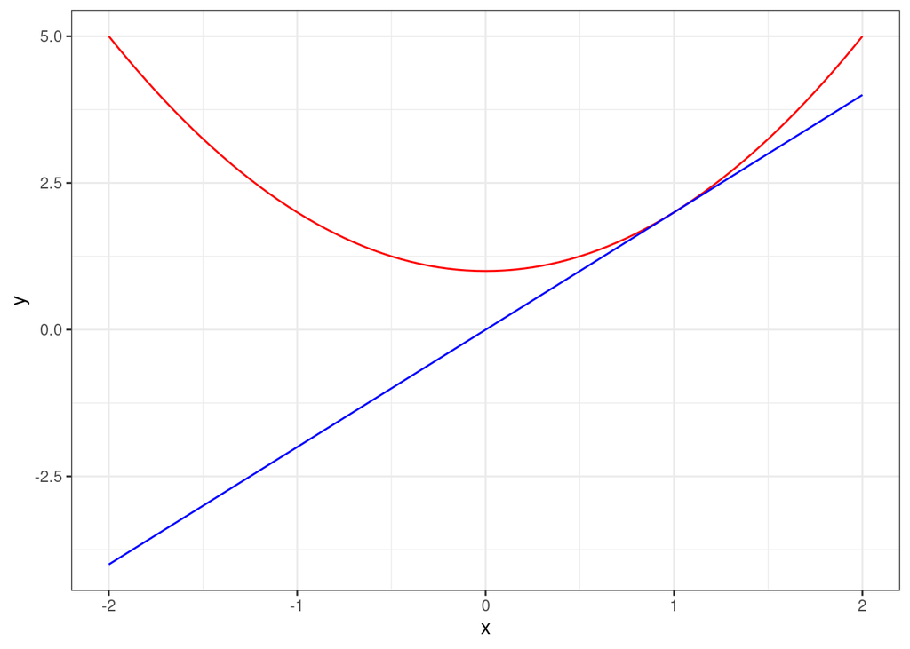

```r
f <- function(x) x^2+1
grad_f <- function(x) 2*x
sample_data = tibble(
  x = seq(-2, 2, by = 0.05),
  y = f(x),
  grad = grad_f(x)
)
base_plot <- ggplot(sample_data, aes(x, y)) + geom_line(color = "red") + geom_line(aes(y = grad), color = "blue") +
  theme_bw()
base_plot
```

Conclusion if we can’t find minimum of afunction $f(x)$ directly, we can always try checking where derivative $f'(x)$ is equal to $0$ (and for multiple solutions check which one is a minimum). That’s great, but what to do when we can’t solve the equation $f'(x) == 0$ ? No problem, we can always use very simple algorithm called **Gradient Descent**:

1. Simply start with a initial value(s) of a parameter(s) (x, y, beta, whatever, …)
2. Update parameter(s) using formula:
   $$param_{new} = param_{old} - LR * f'(param_{old})$$

where $LR$ is a hyperparameter called **learning rate**. Let’s try it for our function. Try out different values of learning rate like $0.1$, $0.01$ and $1$

```
## [1] "Updated x value: 1.076 . Updated f(x) value: 2.157776"
## [1] "Updated x value: 0.8608 . Updated f(x) value: 1.74097664"
## [1] "Updated x value: 0.68864 . Updated f(x) value: 1.47422505"
## [1] "Updated x value: 0.550912 . Updated f(x) value: 1.30350403"
## [1] "Updated x value: 0.4407296 . Updated f(x) value: 1.19424258"
## [1] "Updated x value: 0.35258368 . Updated f(x) value: 1.12431525"
## [1] "Updated x value: 0.28206694 . Updated f(x) value: 1.07956176"
## [1] "Updated x value: 0.22565356 . Updated f(x) value: 1.05091953"
## [1] "Updated x value: 0.18052284 . Updated f(x) value: 1.0325885"
## [1] "Updated x value: 0.14441828 . Updated f(x) value: 1.02085664"
## [1] "Updated x value: 0.11553462 . Updated f(x) value: 1.01334825"
## [1] "Updated x value: 0.0924277 . Updated f(x) value: 1.00854288"
## [1] "Updated x value: 0.07394216 . Updated f(x) value: 1.00546744"
## [1] "Updated x value: 0.05915373 . Updated f(x) value: 1.00349916"
## [1] "Updated x value: 0.04732298 . Updated f(x) value: 1.00223946"
## [1] "Updated x value: 0.03785838 . Updated f(x) value: 1.00143326"
## [1] "Updated x value: 0.03028671 . Updated f(x) value: 1.00091728"
## [1] "Updated x value: 0.02422937 . Updated f(x) value: 1.00058706"
## [1] "Updated x value: 0.01938349 . Updated f(x) value: 1.00037572"
## [1] "Updated x value: 0.01550679 . Updated f(x) value: 1.00024046"
## [1] "Updated x value: 0.01240544 . Updated f(x) value: 1.00015389"
## [1] "Updated x value: 0.00992435 . Updated f(x) value: 1.00009849"
## [1] "Updated x value: 0.00793948 . Updated f(x) value: 1.00006304"
## [1] "Updated x value: 0.00635158 . Updated f(x) value: 1.00004034"
## [1] "Updated x value: 0.00508127 . Updated f(x) value: 1.00002582"
## [1] "Updated x value: 0.00406501 . Updated f(x) value: 1.00001652"
## [1] "Updated x value: 0.00325201 . Updated f(x) value: 1.00001058"
## [1] "Updated x value: 0.00260161 . Updated f(x) value: 1.00000677"
## [1] "Updated x value: 0.00208129 . Updated f(x) value: 1.00000433"
## [1] "Updated x value: 0.00166503 . Updated f(x) value: 1.00000277"
```

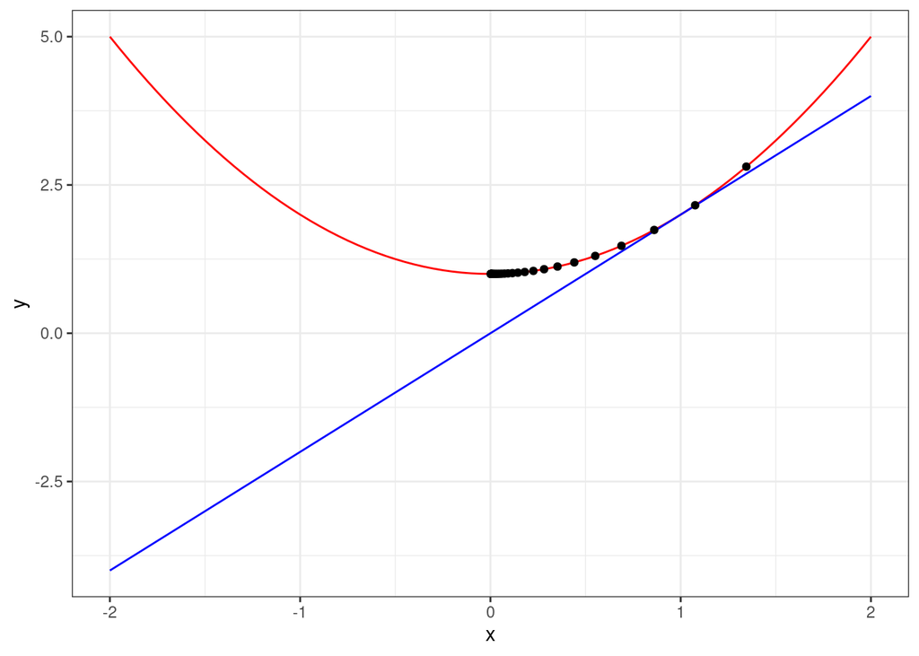

```r
x0 <- 1.345 # Start point
lr <- 0.1 # Learning rate
epochs <- 30 # Nr of epochs (updates)
GD_ordinary_fun <- function(f, grad_f, x0, lr, epochs) {
  x <- x0
  results <- tibble(
    x = x0, y = f(x), grad = grad_f(x)
  )
  for (i in 1:epochs) {
    x <- x - lr * grad_f(x) # GD
    results[i + 1, ] <- list(x, f(x), grad_f(x))
    print(paste("Updated x value:", round(x, 8), ". Updated f(x) value:", round(f(x), 8)))
  }
  plot(base_plot + geom_point(data = results, color = "black"))
  results
}
task1 <- GD_ordinary_fun(f, grad_f, x0, lr, epochs)
```

## 1.2 Gradient Descent for linear regression

If we can now implement Gradient descent for a simple function with one parameter we can try to solve basic machine learning problem - linear regression.

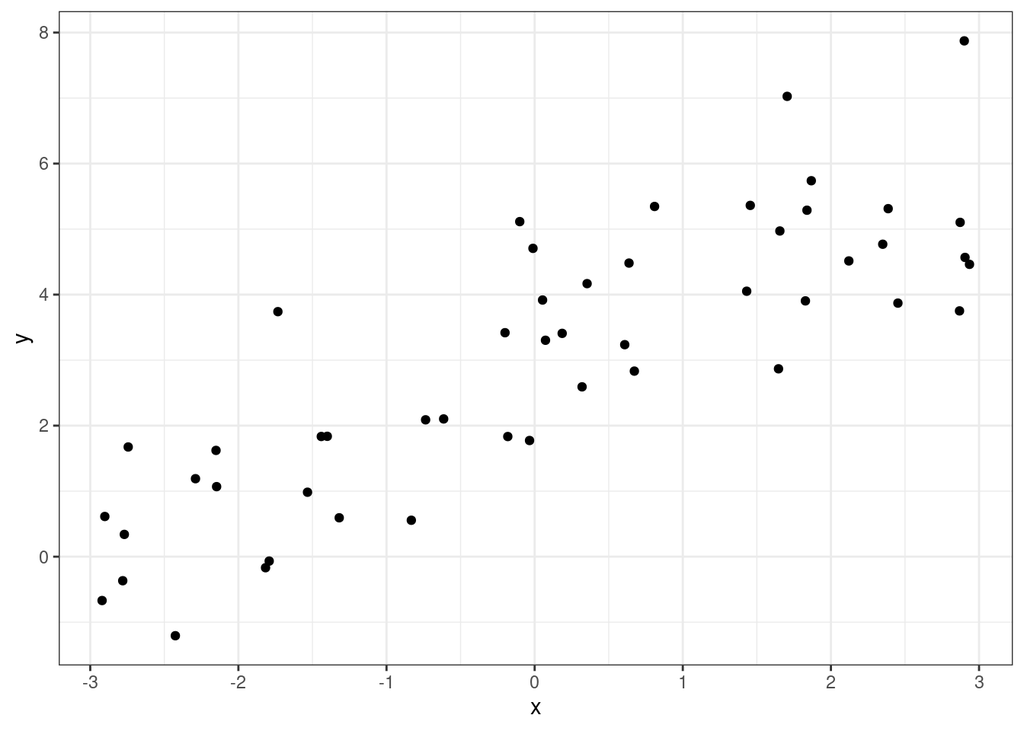

```r
set.seed(666)
sample_data <- tibble(x = runif(50, -3, 3), y = x + rnorm(50, 3, 1.2))
base_plot <- ggplot(sample_data, aes(x, y)) + geom_point() + theme_bw()
base_plot
```

Our task is to find parameters $b_0$ and $b_1$ of the linear regression model $y = b_0 + b_1 x$ such that **mean squared error** is minimized. Before we start let’s check the solution from R:

```r
lm_model <- lm_model <- lm(y ~ x, sample_data)
summary(lm_model)
```

```
##
## Call:
## lm(formula = y ~ x, data = sample_data)
##
## Residuals:
##      Min       1Q   Median       3Q      Max
## -1.88935 -0.85075 -0.09152  0.68110  2.47660
##
## Coefficients:
##             Estimate Std. Error t value Pr(>|t|)
## (Intercept)  2.95039    0.16401   17.99  < 2e-16 ***
## x            0.93806    0.08944   10.49 5.19e-14 ***
## ---
## Signif. codes:  0 '***' 0.001 '**' 0.01 '*' 0.05 '.' 0.1 ' ' 1
##
## Residual standard error: 1.159 on 48 degrees of freedom
## Multiple R-squared:  0.6962, Adjusted R-squared:  0.6899
## F-statistic:   110 on 1 and 48 DF,  p-value: 5.192e-14
```

```r
mean(lm_model$residuals^2) # MSE from model
```

```
## [1] 1.288621
```

Our linear model can be written in a matrix notation as $y = Xb$. Let’s start by creating a matrix of predictors $X$ and a vector of predicted values $y$ from our original data:

```r
X <- tibble(x0 = 1, x1 = sample_data$x) %>% as.matrix()
y <- sample_data$y
```

Now we need to implement MSE:

```r
MSE <- function(beta, X, y) mean((beta%*%t(X) - y)^2)
MSE(c(2.95039, 0.93806), X, y)
```

```
## [1] 1.288621
```

And it’s derivative:

```r
MSE_grad <- function(beta, X, y) 2*((beta%*%t(X) - y)%*%X)/length(y)
```

To be honest, we don’t need to use gradient descent here, equation $MSE_grad == 0$ has a numerical solution:

```r
solve(t(X)%*%X)%*%t(X)%*%y
```

```
##         [,1]
## x0 2.9503910
## x1 0.9380574
```

But let’s say we really want to:

```
## [1] "Updated b0 value: 0.39145154 Updated b1 value: -0.73216064 Updated MSE value: 17.91156864"
## [1] "Updated b0 value: -0.53889493 Updated b1 value: -1.16487183 Updated MSE value: 29.52622784"
## [1] "Updated b0 value: -0.73198697 Updated b1 value: -1.47100026 Updated MSE value: 35.80481334"
## [1] "Updated b0 value: -0.77557373 Updated b1 value: -1.68002735 Updated MSE value: 39.80488262"
## [1] "Updated b0 value: -0.78768352 Updated b1 value: -1.82132042 Updated MSE value: 42.54122856"
## [1] "Updated b0 value: -0.79239861 Updated b1 value: -1.91654666 Updated MSE value: 44.43423586"
## [1] "Updated b0 value: -0.79488712 Updated b1 value: -1.98066965 Updated MSE value: 45.73794054"
## [1] "Updated b0 value: -0.79642551 Updated b1 value: -2.02383733 Updated MSE value: 46.63011608"
## [1] "Updated b0 value: -0.79743379 Updated b1 value: -2.05289566 Updated MSE value: 47.23753881"
## [1] "Updated b0 value: -0.79810705 Updated b1 value: -2.07245582 Updated MSE value: 47.64957719"
## [1] "Updated b0 value: -0.79855916 Updated b1 value: -2.08562236 Updated MSE value: 47.92837595"
## [1] "Updated b0 value: -0.79886327 Updated b1 value: -2.09448514 Updated MSE value: 48.1166996"
## [1] "Updated b0 value: -0.79906793 Updated b1 value: -2.10045093 Updated MSE value: 48.24376335"
## [1] "Updated b0 value: -0.79920568 Updated b1 value: -2.10446667 Updated MSE value: 48.32942855"
## [1] "Updated b0 value: -0.79929841 Updated b1 value: -2.10716978 Updated MSE value: 48.38715341"
## [1] "Updated b0 value: -0.79936082 Updated b1 value: -2.10898932 Updated MSE value: 48.42603737"
## [1] "Updated b0 value: -0.79940284 Updated b1 value: -2.1102141 Updated MSE value: 48.45222383"
## [1] "Updated b0 value: -0.79943112 Updated b1 value: -2.11103853 Updated MSE value: 48.46985637"
## [1] "Updated b0 value: -0.79945015 Updated b1 value: -2.11159349 Updated MSE value: 48.48172791"
## [1] "Updated b0 value: -0.79946297 Updated b1 value: -2.11196704 Updated MSE value: 48.48972014"
## [1] "Updated b0 value: -0.79947159 Updated b1 value: -2.11221849 Updated MSE value: 48.49510047"
## [1] "Updated b0 value: -0.7994774 Updated b1 value: -2.11238775 Updated MSE value: 48.49872237"
## [1] "Updated b0 value: -0.79948131 Updated b1 value: -2.11250168 Updated MSE value: 48.50116047"
## [1] "Updated b0 value: -0.79948394 Updated b1 value: -2.11257837 Updated MSE value: 48.50280168"
## [1] "Updated b0 value: -0.79948571 Updated b1 value: -2.11262999 Updated MSE value: 48.50390645"
## [1] "Updated b0 value: -0.7994869 Updated b1 value: -2.11266474 Updated MSE value: 48.50465011"
## [1] "Updated b0 value: -0.7994877 Updated b1 value: -2.11268813 Updated MSE value: 48.50515069"
## [1] "Updated b0 value: -0.79948824 Updated b1 value: -2.11270388 Updated MSE value: 48.50548765"
## [1] "Updated b0 value: -0.79948861 Updated b1 value: -2.11271447 Updated MSE value: 48.50571447"
## [1] "Updated b0 value: -0.79948885 Updated b1 value: -2.11272161 Updated MSE value: 48.50586714"
```

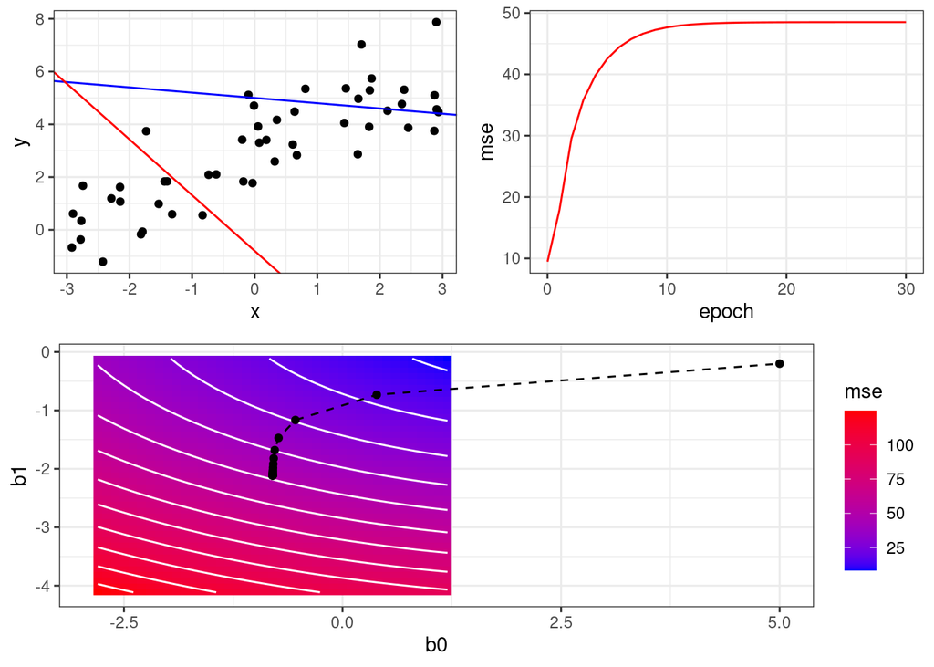

```r
beta00 <- c(5, -0.2) # Start point
lr <- 0.1 # Learning rate
epochs <- 30 # Nr of epochs
GD_linear_regression <- function(beta00, X, y, lr, epochs) {
  beta <- beta00
  results <- tibble(
    b0 = beta00[1], b1 = beta00[2], mse = MSE(beta00, X, y), epoch = 0
  )
  for (i in 1:epochs) {
    beta <- lr * MSE_grad(beta, X, y) # GD
    results[i + 1, ] <- list(beta[1], beta[2], MSE(beta, X, y), i)
    print(paste("Updated b0 value:", round(beta[1], 8),
                "Updated b1 value:", round(beta[2], 8),
                "Updated MSE value:", round(MSE(beta, X, y), 8)))
  }
  # Diagnostic plots
  p1 <- base_plot + geom_abline(intercept = beta00[1], slope = beta00[2], color = "blue") +
    geom_abline(intercept = beta[1], slope = beta[2], color = "red")
  p2 <- ggplot(results, aes(epoch, mse)) + theme_bw() + geom_line(color = "red")
  lin_space <- expand.grid(seq(beta[1] - 2, beta[1] + 2, by = 0.1),
                           seq(beta[2] - 2, beta[2] + 2, by = 0.1)) %>%
    as.data.frame() %>% set_names(c("b0", "b1")) %>% rowwise() %>%
    mutate(mse = MSE(c(b0, b1), X, y))
  p3 <- ggplot(lin_space, aes(b0, b1)) + theme_bw() + geom_raster(aes(fill = mse)) +
    geom_contour(colour = "white", aes(z = mse)) + scale_fill_gradient(low = "blue", high = "red") +
    geom_line(data = results, color = "black", linetype = "dashed") +
    geom_point(data = results, color = "black")
  grid.arrange(p1, p2, p3, layout_matrix = rbind(c(1, 2), c(3, 3)))
  results
}
task2 <- GD_linear_regression(beta00, X, y, lr, epochs)
```

## 1.3 Stochastic Gradient Descent for linear regression

We know now what is gradient descent and how to use it to solve ML problems. In reality we will often use an advanced version of gradient descent called **Stochastic Gradient Descent** or **SGD** for short. We will introduce one small change in our algorithm. As you remember our MSE gradient $MSE_grad$ takes into calculation matrix $X$ and vector $y$ and multiplies them in different ways. Assume for a moment that we have millions of observations, those multiplications can take a lot of time and memory, it could be even impossible to do it. There’s an easy solution for this problem. We can split our data into so called **batches**. If we have for example 50 observations we can divide them into 5 batches - 10 observations each. After this 5 batches SGD will see all the observations we had - the first **epoch** will pass and the process will start from the beginning. You can think of it as an extra loop over batches inside the epoch loop from GD implementation.

```
## [1] "Updated b0 value: 2.98172033 Updated b1 value: 0.53373089 Updated MSE value: 1.83730671"
## [1] "Updated b0 value: 2.92348075 Updated b1 value: 0.55605676 Updated MSE value: 1.78173712"
## [1] "Updated b0 value: 2.9217933 Updated b1 value: 0.55670364 Updated MSE value: 1.78027184"
## [1] "Updated b0 value: 2.9217444 Updated b1 value: 0.55672238 Updated MSE value: 1.7802295"
## [1] "Updated b0 value: 2.92174299 Updated b1 value: 0.55672292 Updated MSE value: 1.78022828"
## [1] "Updated b0 value: 2.92174295 Updated b1 value: 0.55672294 Updated MSE value: 1.78022824"
## [1] "Updated b0 value: 2.92174294 Updated b1 value: 0.55672294 Updated MSE value: 1.78022824"
## [1] "Updated b0 value: 2.92174294 Updated b1 value: 0.55672294 Updated MSE value: 1.78022824"
## [1] "Updated b0 value: 2.92174294 Updated b1 value: 0.55672294 Updated MSE value: 1.78022824"
## [1] "Updated b0 value: 2.92174294 Updated b1 value: 0.55672294 Updated MSE value: 1.78022824"
## [1] "Updated b0 value: 2.92174294 Updated b1 value: 0.55672294 Updated MSE value: 1.78022824"
## [1] "Updated b0 value: 2.92174294 Updated b1 value: 0.55672294 Updated MSE value: 1.78022824"
## [1] "Updated b0 value: 2.92174294 Updated b1 value: 0.55672294 Updated MSE value: 1.78022824"
## [1] "Updated b0 value: 2.92174294 Updated b1 value: 0.55672294 Updated MSE value: 1.78022824"
## [1] "Updated b0 value: 2.92174294 Updated b1 value: 0.55672294 Updated MSE value: 1.78022824"
```

[output cut: 35 more lines]

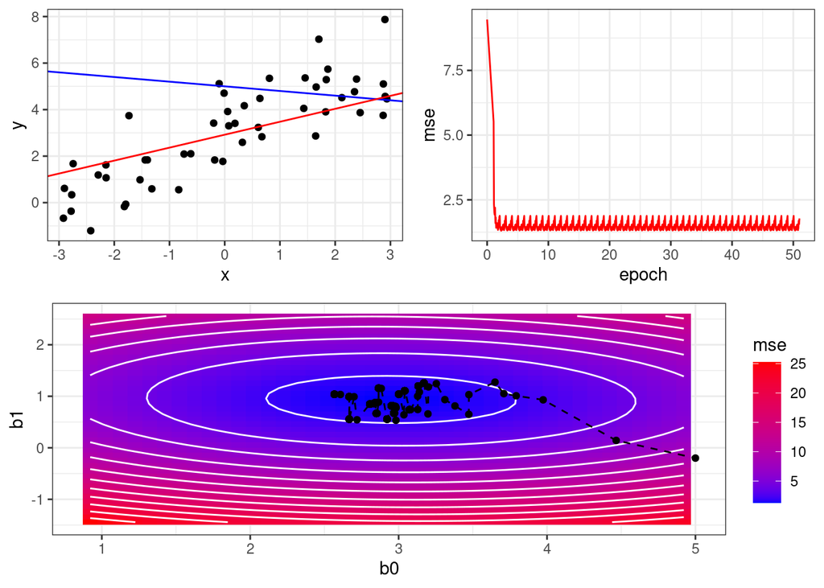

```r
beta00 <- c(5, -0.2) # Start point
lr <- 0.1 # Learning rate
epochs <- 50 # Nr of epochs
batch_size <- 3 # Batch size
SGD_linear_regression <- function(beta00, X, y, lr, epochs, batch_size) {
  beta <- beta00
  results <- tibble(
    b0 = beta00[1], b1 = beta00[2], mse = MSE(beta00, X, y), epoch = 0
  )
  batches_per_epoch <- ceiling(length(y) / batch_size)
  for (i in 1:epochs) {
    for (b in 1:batches_per_epoch) {
      indexes <- ((b - 1) * batch_size + 1):min((b * batch_size), length(y))
      X_b <- X[indexes, , drop = FALSE]
      y_b <- y[indexes]
      beta <- beta - lr * MSE_grad(beta, X_b, y_b)# SGD
      results <- rbind(results, c(beta[1], beta[2], MSE(beta, X, y), i + b / batches_per_epoch))
    }
    print(paste("Updated b0 value:", round(beta[1], 8),
                "Updated b1 value:", round(beta[2], 8),
                "Updated MSE value:", round(MSE(beta, X, y), 8)))
  }
  # Diagnostic plots
  p1 <- base_plot + geom_abline(intercept = beta00[1], slope = beta00[2], color = "blue") +
    geom_abline(intercept = beta[1], slope = beta[2], color = "red")
  p2 <- ggplot(results, aes(epoch, mse)) + theme_bw() + geom_line(color = "red")
  lin_space <- expand.grid(seq(beta[1] - 2, beta[1] + 2, by = 0.1),
                           seq(beta[2] - 2, beta[2] + 2, by = 0.1)) %>%
    as.data.frame() %>% set_names(c("b0", "b1")) %>% rowwise() %>%
    mutate(mse = MSE(c(b0, b1), X, y))
  p3 <- ggplot(lin_space, aes(b0, b1)) + theme_bw() + geom_raster(aes(fill = mse)) +
    geom_contour(colour = "white", aes(z = mse)) + scale_fill_gradient(low = "blue", high = "red") +
    geom_line(data = results, color = "black", linetype = "dashed") +
    geom_point(data = results, color = "black")
  grid.arrange(p1, p2, p3, layout_matrix = rbind(c(1, 2), c(3, 3)))
  results
}
task3 <- SGD_linear_regression(beta00, X, y, lr, epochs, batch_size)
```

In case of SGD, computations needed for parameter updates are faster than in GD, but SGD could need more steps than GD to minimize the function. There is another important advantage of SGD over GD - SGD can “get out” from local minimum.

## 1.4 Stochastic Gradient Descent for logistic regression

Another step in understanding optimization process will be implementation of SGD for logistic regression. In case of logistic regression there’s no numerical solution so we have to use some algorithm

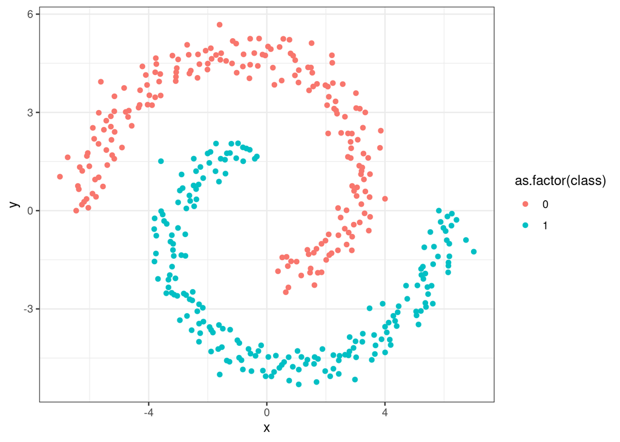

```r
sample_data <- readRDS("spirals.RDS")
base_plot <- ggplot(sample_data, aes(x, y, color = as.factor(class))) + geom_point() + theme_bw()
base_plot
```

As always we can check solution in R. R uses Fisher Scoring Algorithm or Newton Scoring Algorithm - those algorithms are using not only first but also second derivative to update parameters. Using second derivative has advantages but calculations are really time and memory consuming.

```r
logistic_model <- glm(class ~ x + y, sample_data, family = "binomial")
summary(logistic_model)
```

```
##
## Call:
## glm(formula = class ~ x + y, family = "binomial", data = sample_data)
##
## Deviance Residuals:
##      Min        1Q    Median        3Q       Max
## -2.05011  -0.48064   0.01074   0.46293   1.88937
##
## Coefficients:
##              Estimate Std. Error z value Pr(>|z|)
## (Intercept)  0.002199   0.147139   0.015    0.988
## x           -0.050317   0.039784  -1.265    0.206
## y           -0.803763   0.077752 -10.337   <2e-16 ***
## ---
## Signif. codes:  0 '***' 0.001 '**' 0.01 '*' 0.05 '.' 0.1 ' ' 1
##
## (Dispersion parameter for binomial family taken to be 1)
##
##     Null deviance: 554.52  on 399  degrees of freedom
## Residual deviance: 294.00  on 397  degrees of freedom
## AIC: 300
##
## Number of Fisher Scoring iterations: 5
```

As in linear regression we will create prediction matrix and vector of predicted values:

```r
X <- tibble(x0 = 1, x1 = sample_data$x, x2 = sample_data$y) %>% as.matrix()
y <- sample_data$class
```

Next step is to implement **sigmoid** function used in logistic regression:

```r
sigmoid <- function(x) 1 / (1 + exp(-x))
```

And its gradient:

```r
sigmoid_grad <- function(x) sigmoid(x) * (1 - sigmoid(x))
```

In case of binary classification our loss function will be **binary crossentropy**:

```r
binary_crossentropy <- function(beta, X, y) {
  z <- sigmoid(beta%*%t(X))
  -mean(y * log(z) + (1 - y) * log(1 - z))
}
```

We also need the gradient. Here we will use so called **chain rule** for derivatives:

```r
binary_crossentropy_grad <- function(beta, X, y) {
  z <- sigmoid(beta%*%t(X))
  dL <- (-y / z - (1 - y) / (z - 1)) / length(y)
  dV <- sigmoid_grad(beta%*%t(X))
  dx <- X
  (dL * dV) %*% dx
}
```

Now we have everything to implement SGD for logistic regression:

```
## [1] "Updated b0 value: 0.22218413 Updated b1 value: 0.01697509 Updated b2 value: -0.65215424 Updated LogLoss value: 0.37766047"
## [1] "Updated b0 value: 0.17218434 Updated b1 value: -0.04357743 Updated b2 value: -0.76515555 Updated LogLoss value: 0.36954557"
## [1] "Updated b0 value: 0.13691386 Updated b1 value: -0.05563991 Updated b2 value: -0.80650355 Updated LogLoss value: 0.36856906"
## [1] "Updated b0 value: 0.11007267 Updated b1 value: -0.06039136 Updated b2 value: -0.82305645 Updated LogLoss value: 0.36827665"
## [1] "Updated b0 value: 0.08915834 Updated b1 value: -0.06247054 Updated b2 value: -0.82991202 Updated LogLoss value: 0.36811544"
## [1] "Updated b0 value: 0.07270786 Updated b1 value: -0.06343093 Updated b2 value: -0.83275576 Updated LogLoss value: 0.36800549"
## [1] "Updated b0 value: 0.05971654 Updated b1 value: -0.06390056 Updated b2 value: -0.83391572 Updated LogLoss value: 0.36792862"
## [1] "Updated b0 value: 0.04943918 Updated b1 value: -0.0641479 Updated b2 value: -0.83437382 Updated LogLoss value: 0.36787564"
## [1] "Updated b0 value: 0.04130272 Updated b1 value: -0.06429067 Updated b2 value: -0.83454579 Updated LogLoss value: 0.36783963"
## [1] "Updated b0 value: 0.03485913 Updated b1 value: -0.06438145 Updated b2 value: -0.83460565 Updated LogLoss value: 0.36781537"
## [1] "Updated b0 value: 0.02975553 Updated b1 value: -0.06444425 Updated b2 value: -0.83462445 Updated LogLoss value: 0.36779908"
## [1] "Updated b0 value: 0.02571306 Updated b1 value: -0.06449046 Updated b2 value: -0.83462998 Updated LogLoss value: 0.36778811"
## [1] "Updated b0 value: 0.02251103 Updated b1 value: -0.06452581 Updated b2 value: -0.83463232 Updated LogLoss value: 0.3677807"
## [1] "Updated b0 value: 0.01997472 Updated b1 value: -0.06455346 Updated b2 value: -0.83463461 Updated LogLoss value: 0.36777564"
## [1] "Updated b0 value: 0.01796571 Updated b1 value: -0.06457533 Updated b2 value: -0.83463744 Updated LogLoss value: 0.36777217"
```

[output cut: 35 more lines]

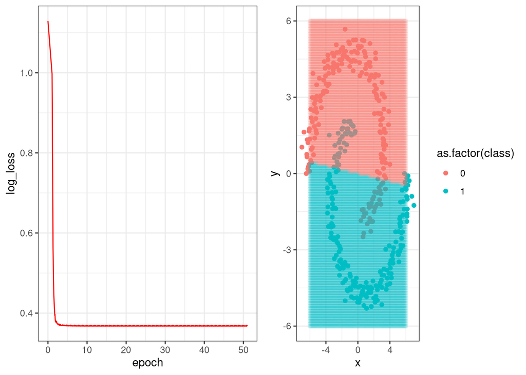

```r
beta00 <- c(0.3, 1, -0.2) # Start point
lr <- 0.1 # Learning rate
epochs <- 50 # Nr of epochs
batch_size <- 20 # Batch size
SGD_logistic_regression <- function(beta00, X, y, lr, epochs, batch_size) {
  beta <- beta00
  results <- tibble(
    b0 = beta00[1], b1 = beta00[2], b2 = beta00[3], log_loss = binary_crossentropy(beta00, X, y), epoch = 0
  )
  batches_per_epoch <- ceiling(length(y) / batch_size)
  for (i in 1:epochs) {
    for (b in 1:batches_per_epoch) {
      indexes <- ((b - 1) * batch_size + 1):min((b * batch_size), length(y))
      X_b <- X[indexes, , drop = FALSE]
      y_b <- y[indexes]
      beta <- beta - lr * binary_crossentropy_grad(beta, X_b, y_b) # SGD
      results <- rbind(results, c(beta[1], beta[2], beta[3], binary_crossentropy(beta, X, y), i + b / batches_per_epoch))
    }
    print(paste("Updated b0 value:", round(beta[1], 8),
                "Updated b1 value:", round(beta[2], 8),
                "Updated b2 value:", round(beta[3], 8),
                "Updated LogLoss value:", round(binary_crossentropy(beta, X, y), 8)))
  }
  # Diagnostic plots
  p1 <- ggplot(results, aes(epoch, log_loss)) + theme_bw() + geom_line(color = "red")
  lin_space <- expand.grid(seq(-6, 6, by = 0.1), seq(-6, 6, by = 0.1)) %>%
    as.data.frame() %>% set_names(c("x", "y")) %>% rowwise() %>%
    mutate(proba = sigmoid(beta%*%c(1, x, y)),
           class = ifelse(proba > 0.5, 1, 0))
  p2 <- base_plot + geom_point(data = lin_space, alpha = 0.1)
  grid.arrange(p1, p2, ncol = 2)
  results
}
task4 <- SGD_logistic_regression(beta00, X, y, lr, epochs, batch_size)
```

## 1.5 Stochastic Gradient Descent for single layer perceptron

Our last task is to implement basic **single layer perceptron** for the same classification task. The difference here is that we will have to update weights for every hidden layer of the neural network using chain rule for derivatives as in logistic regression example. Weights of the n-th layer are dependent at weights of the n-1 previous layers. This version of SGD in neural networks is called **backpropagation** algorithm.

We will start by implementing **forward step**, which means calculating output of the network for a given set of weights:

```r
forward_propagation <- function(X, w1, w2) {
  # Linear combination of inputs and weights
  z1 <- X %*% w1
  # Activation function - sigmoid
  h <- sigmoid(z1)
  # Linear combination of 1-layer hidden units and weights
  z2 <- cbind(1, h) %*% w2
  # Output
  list(output = sigmoid(z2), h = h)
}
```

Now it’s time for backpropagation. For the simplicity we will use MSE as and error:

```r
backward_propagation <- function(X, y, y_hat, w1, w2, h, lr) {
  # w2 gradient
  dw2 <- t(cbind(1, h)) %*% (y_hat - y)
  # h gradient
  dh  <- (y_hat - y) %*% t(w2[-1, , drop = FALSE])
  # w1 gradient
  dw1 <- t(X) %*% ((h * (1 - h) * dh))
  # SGD
  w1 <- w1 - lr * dw1
  w2 <- w2 - lr * dw2
  list(w1 = w1, w2 = w2)
}
```

Putting it all together:

```
## [1] "Updated MSE value: 0.14815415"
## [1] "Updated MSE value: 0.12610701"
## [1] "Updated MSE value: 0.12009348"
## [1] "Updated MSE value: 0.11607886"
## [1] "Updated MSE value: 0.09938857"
## [1] "Updated MSE value: 0.08310776"
## [1] "Updated MSE value: 0.06802051"
## [1] "Updated MSE value: 0.05180404"
## [1] "Updated MSE value: 0.03874258"
## [1] "Updated MSE value: 0.0292425"
## [1] "Updated MSE value: 0.0220797"
## [1] "Updated MSE value: 0.02160164"
## [1] "Updated MSE value: 0.01316436"
## [1] "Updated MSE value: 0.01093863"
## [1] "Updated MSE value: 0.01177764"
```

[output cut: 35 more lines]

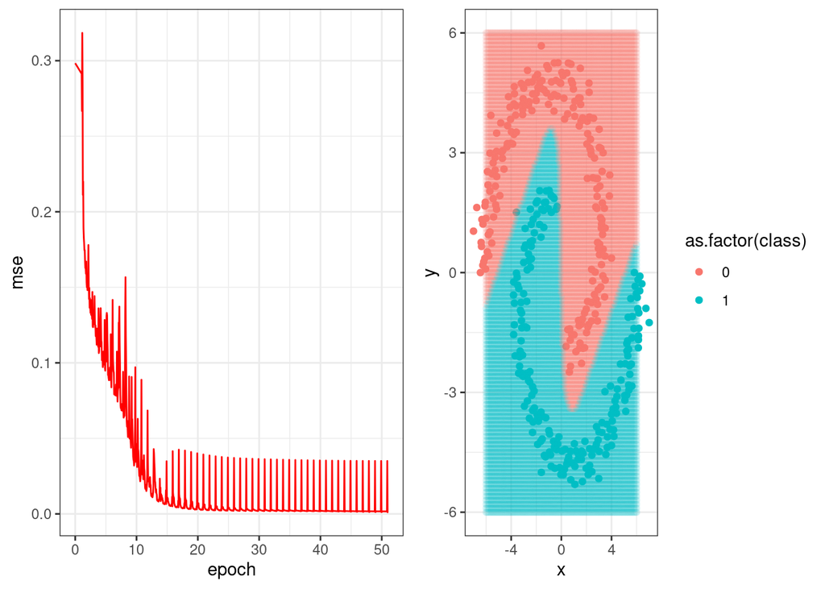

```r
hidden_units <- 5
set.seed(666)
w1 <- matrix(rnorm(3 * hidden_units), 3, hidden_units)
w2 <- as.matrix(rnorm(hidden_units + 1))
lr <- 0.1 # Learning rate
epochs <- 50 # Nr of epochs
batch_size <- 20 # Batch size
SGD_single_layer_perceptron <- function(w100, w200, X, y, lr, epochs, batch_size) {
  w1 <- w100
  w2 <- w200
  results <- tibble(
    mse = mean((forward_propagation(X, w1, w2)$output - y)^2), epoch = 0
  )
  batches_per_epoch <- ceiling(length(y) / batch_size)
  for (i in 1:epochs) {
    for (b in 1:batches_per_epoch) {
      indexes <- ((b - 1) * batch_size + 1):min((b * batch_size), length(y))
      X_b <- X[indexes, , drop = FALSE]
      y_b <- y[indexes]
      ff <- forward_propagation(X_b, w1, w2)
      bp <- backward_propagation(X_b, y_b,
                                 y_hat = ff$output,
                                 w1, w2,
                                 h = ff$h,
                                 lr = lr)
      w1 <- bp$w1
      w2 <- bp$w2
      results <- rbind(results, c(mean((forward_propagation(X, w1, w2)$output - y)^2), i + b / batches_per_epoch))
    }
    print(paste("Updated MSE value:", round(mean((forward_propagation(X, w1, w2)$output - y)^2), 8)))
  }
  # Diagnostic plots
  p1 <- ggplot(results, aes(epoch, mse)) + theme_bw() + geom_line(color = "red")
  lin_space <- expand.grid(seq(-6, 6, by = 0.1), seq(-6, 6, by = 0.1)) %>%
    as.data.frame() %>% set_names(c("x", "y")) %>% rowwise() %>%
    mutate(proba = forward_propagation(c(1, x, y), w1, w2)$output,
           class = ifelse(proba > 0.5, 1, 0))
  p2 <- base_plot + geom_point(data = lin_space, alpha = 0.1)
  grid.arrange(p1, p2, ncol = 2)
  results
}
task5 <- SGD_single_layer_perceptron(w1, w2, X, y, lr, epochs, batch_size)
```